# Exploratory Data Analysis for AirBnB

Ekaterina Mazanchenko

# Project description:

Create a Shiny application that allows to explore the `AirBnB data (Paris data)`. A minimal application should contains:

- Relationship between prices and apartment features,
- Number of apartments per owner,
- Renting price per city quarter (“arrondissements”),
- Visit frequency of the different quarters according to time.

The data are available at *https://plmbox.math.cnrs.fr/f/6b0e16bbf4974b78ba01/?dl=1*

The `application` should be accompanied by a `R markdown document` explaining the different step of the analysis and providing some personal scientific comments on the data, based on statistical results.

```r
#install.packages('dplyr')
library(dplyr)
load(url('https://plmbox.math.cnrs.fr/f/6b0e16bbf4974b78ba01/?dl=1'))
```

# Dataset observation:

- L: The dataset describes AirBnB properties in Paris from 2009 to 2016, with 52725 items in 95 variables.

```
## [1] 52725    95
```

- R: The dataset contains visit records for properties from L.

```
## [1] 663599      2
```

- Variables type:

```
##
##  factor integer logical numeric
##      64      24       2       5
```

# Data cleaning:

## Missing values:

```r
#install.packages(visdat)
#install.packages(naniar)
library(visdat)
library(naniar)
```

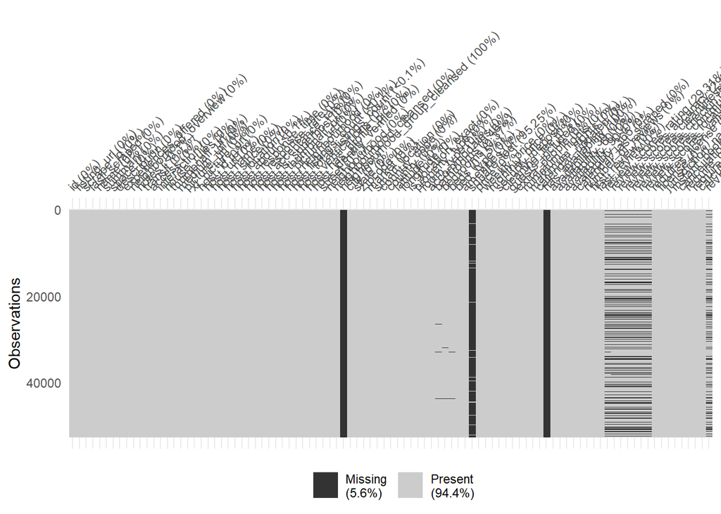

```r
vis_miss(L, warn_large_data = FALSE)
```

Number of missing values in L:

```
## [1] 279634
```

```r
miss_var_summary(L)
```

```
## # A tibble: 95 x 3
##    variable                     n_miss pct_miss
##    <chr>                         <int>    <dbl>
##  1 neighbourhood_group_cleansed  52725    100
##  2 has_availability              52725    100
##  3 square_feet                   50218     95.2
##  4 review_scores_checkin         15579     29.5
##  5 review_scores_accuracy        15575     29.5
##  6 review_scores_cleanliness     15566     29.5
##  7 review_scores_location        15560     29.5
##  8 review_scores_value           15559     29.5
##  9 review_scores_communication   15543     29.5
## 10 review_scores_rating          15454     29.3
## # ... with 85 more rows
```

```r
sum(is.na(L$review_scores_rating))
```

```
## [1] 15454
```

What is 29.31% of the variable data. I’ll keep one of review_scores, `review_scores_rating` for complementary information.

## Variables summary:

We can explore variables properties.

```r
levels(L$neighbourhood_cleansed)
```

```
##  [1] "Batignolles-Monceau" "Bourse"              "Buttes-Chaumont"
##  [4] "Buttes-Montmartre"   "Ã‰lysÃ©e"            "EntrepÃ´t"
##  [7] "Gobelins"            "HÃ´tel-de-Ville"     "Louvre"
## [10] "Luxembourg"          "MÃ©nilmontant"       "Observatoire"
## [13] "OpÃ©ra"              "Palais-Bourbon"      "PanthÃ©on"
## [16] "Passy"               "Popincourt"          "Reuilly"
## [19] "Temple"              "Vaugirard"
```

```r
levels(L$experiences_offered)
```

```
## [1] "none"
```

```r
no_prop_types <- L %>% count(property_type)
no_prop_types = arrange(no_prop_types, desc(n))
no_prop_types
```

```
##      property_type     n
## 1        Apartment 50663
## 2             Loft   567
## 3            House   537
## 4  Bed & Breakfast   394
## 5      Condominium   266
## 6            Other   122
## 7        Townhouse    88
## 8             Boat    29
## 9             Dorm    29
## 10           Villa    14
## 11       Camper/RV     4
## 12                     3
## 13          Chalet     2
## 14           Cabin     1
## 15            Cave     1
## 16     Earth House     1
## 17           Igloo     1
## 18            Tent     1
## 19            Tipi     1
## 20       Treehouse     1
```

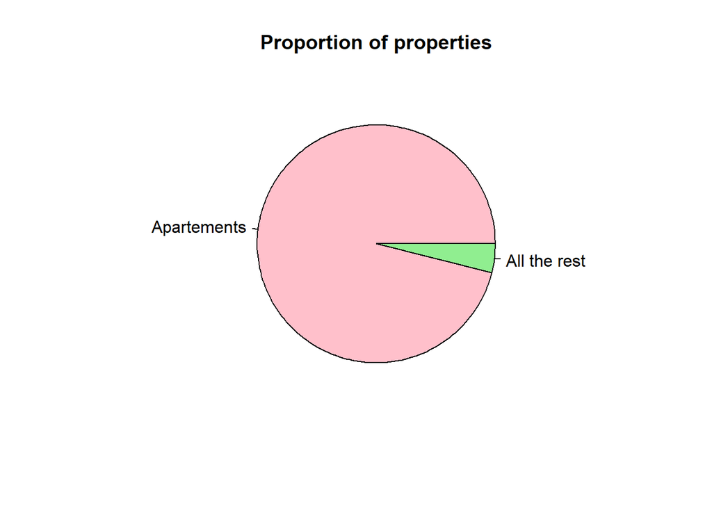

Apartments represents 96.09% of all properties on the market.

```r
summary(L$accommodates)
```

```
##    Min. 1st Qu.  Median    Mean 3rd Qu.    Max.
##   1.000   2.000   2.000   3.051   4.000  16.000
```

```r
L %>% count(bed_type)
```

```
##        bed_type     n
## 1        Airbed    35
## 2         Couch  1182
## 3         Futon   449
## 4 Pull-out Sofa  5066
## 5      Real Bed 45993
```

```r
levels(L$cancellation_policy)
```

```
## [1] "flexible"        "moderate"        "strict"          "super_strict_30"
## [5] "super_strict_60"
```

## Deleting non-essential or not-useful columns:

```r
L_filtered <- select(L, id, host_id, host_name, name, listing_url, street, neighbourhood_cleansed, zipcode, latitude, longitude, property_type, room_type, accommodates, bedrooms, bathrooms, beds, bed_type, price, weekly_price, guests_included, availability_30, review_scores_rating, cancellation_policy)
```

Redused dataset dimentions:

```
## [1] 52725    23
```

## Cleaning unpropre value types:

```r
L_filtered$bathrooms <- as.integer(L_filtered$bathrooms)
L_filtered$price <- as.numeric(gsub('\\$|,', '', L_filtered$price))
L_filtered$weekly_price <- as.numeric(gsub('\\$|,', '', L_filtered$weekly_price))
L_filtered$zipcode <- as.numeric(as.character(L_filtered$zipcode))
```

```r
sum(is.na(L_filtered$weekly_price))/length(L_filtered$weekly_price)*100
```

```
## [1] 56.96349
```

# For future map, it can be useful to group apartments by districts:

```r
L_filtered %>% count(zipcode)%>%
  head(20)
```

```
##    zipcode    n
## 1       75    5
## 2     7009    1
## 3     7517    1
## 4    13006    1
## 5    17200    1
## 6    74000    1
## 7    75000    1
## 8    75001 1101
## 9    75002 1565
## 10   75003 1942
## 11   75004 1800
## 12   75005 1990
## 13   75006 1825
## 14   75007 1525
## 15   75008 1411
## 16   75009 2318
## 17   75010 3511
## 18   75011 4825
## 19   75012 2082
## 20   75013 1858
```

Actually missing:

```
## [1] 514
```

0.97% of data.

## Zipcode replacement by district (`arrondissements`):

I consider last 2 digits in 75XXX code to be a Paris intra muros district, and first 2 in 9XXXX for suburb area.

```r
arr <- {}
for (i in 1:length(L_filtered$zipcode)){
  if (!is.na(L_filtered$zipcode[i])){
    if ((L_filtered$zipcode[i] > 75000) & (L_filtered$zipcode[i] <= 75120)){
      arr[i] <- L_filtered$zipcode[i] - round(L_filtered$zipcode[i], -2)
    } else if ((L_filtered$zipcode[i] > 90000) & (L_filtered$zipcode[i] <= 99000)){
       arr[i] <- L_filtered$zipcode[i]%/%1000
    }
  }
}
L_filtered <- cbind(L_filtered,arr)
L_filtered <- L_filtered[,c(1:8,24,9:23)]
```

After treatment:

```r
L_filtered %>% count(arr)
```

```
##    arr    n
## 1    1 1101
## 2    2 1565
## 3    3 1942
## 4    4 1800
## 5    5 1990
## 6    6 1826
## 7    7 1525
## 8    8 1411
## 9    9 2318
## 10  10 3511
## 11  11 4825
## 12  12 2082
## 13  13 1858
## 14  14 2093
## 15  15 3799
## 16  16 2902
## 17  17 3465
## 18  18 5973
## 19  19 2652
## 20  20 2859
## 21  91    1
## 22  92  342
## 23  93  138
## 24  94  211
## 25  95    5
## 26  NA  531
```

New missing data is:

```
## [1] 531
```

What is 1.01%. Several `NA` values were added due to their original format. We can try to fix it and to obtain initially missed districts by coordinates with `banR`library.

## Temporary dataframe for missed districts:

```r
missed_arr = data.frame(matrix(ncol = 5, nrow=0))
colnames(missed_arr) <- c('id','street','latitude', 'longitude', 'zipcode')

for (i in 1:length(L_filtered$arr)){
  if (is.na(L_filtered$arr[i])){
    missed_arr <- rbind(missed_arr, L_filtered[i,c(1,6,10,11,8)])
  }
}
```

```r
#install.packages(banR)
#install.packages(stringr)
library(banR)
library(stringr)
```

## Extracting districts by coordinates with `banR`:

```r
arr_temp <- vector('list', length(missed_arr$zipcode))

for (i in 1:length(missed_arr$zipcode)){
  arr_temp[[i]] <- as.integer(str_extract(reverse_geocode(long =  missed_arr$longitude[i],
                                            lat = missed_arr$latitude[i])[11],'[[:digit:]]+'))
arr2 <- as.data.frame(do.call(rbind, arr_temp))
colnames(arr2) <- ('arr2')
}
```

```r
for (i in 1:length(L_filtered$arr)){
  if (is.na(L_filtered$arr[i])){
    num <- L_filtered$id[i]
    for (j in 1:length(missed_arr$arr2)){
      if (missed_arr$id[j] == num){
        L_filtered$arr[i] <- missed_arr$arr2[j]
      }
    }
  }
}
```

```r
sum(is.na(L_filtered$arr))
```

```
## [1] 14
```

We succeed to arrive to 14 NA from 531. The treatments by `banR` is heavy, so we can stop here with 0.03% of NA in order to not supercharged more calculations.

# Statistics:

## Number of apartments per owner:

```r
#install.packages('ggplot2')
library(ggplot2)
```

There are 44874 unique hosts on the market. The summary about their properties:

```r
no_prop <- L %>% count(host_id) %>%
           arrange(desc(n))

numb_hosts <- L %>% count(host_id)%>%
              count(n) %>%
              arrange(n)

colnames(numb_hosts) <- c('no_aparts', 'no_pers')
head(numb_hosts, 10)
```

```
##    no_aparts no_pers
## 1          1   41562
## 2          2    2492
## 3          3     404
## 4          4     125
## 5          5      61
## 6          6      35
## 7          7      23
## 8          8      22
## 9          9      15
## 10        10       9
```

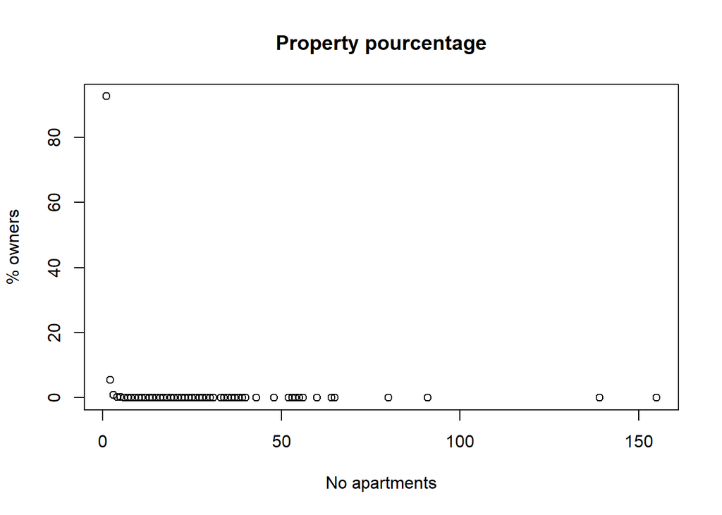

```r
plot(x = numb_hosts$no_aparts, y = numb_hosts$no_pers*100/44874, main = 'Property pourcentage', xlab = 'No apartments', ylab = '% owners')
```

92.6% of owners propose 1 apartment.

```r
summary(numb_hosts$no_aparts)
```

```
##    Min. 1st Qu.  Median    Mean 3rd Qu.    Max.
##    1.00   14.00   27.00   34.02   43.00  155.00
```

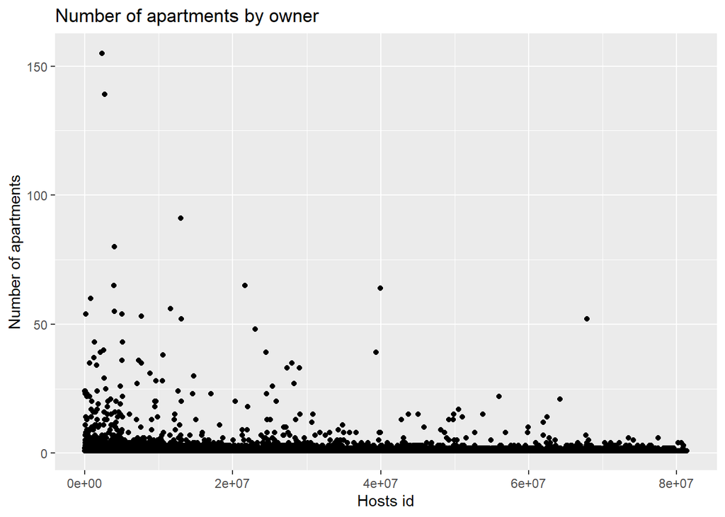

```r
ggplot(data = no_prop) +
  geom_point(aes(x = host_id, y = n)) +
  ggtitle('Number of apartments by owner') +
  xlab('Hosts id') +
  ylab('Number of apartments')
```

## Relationship between prices and apartment features:

```r
L_filtered %>% count(price>1000)
```

```
##   price > 1000     n
## 1        FALSE 52676
## 2         TRUE    49
```

Number of apartments exceed $1000 represents 0.09% so to scale the plots below I will limit it to 1000.

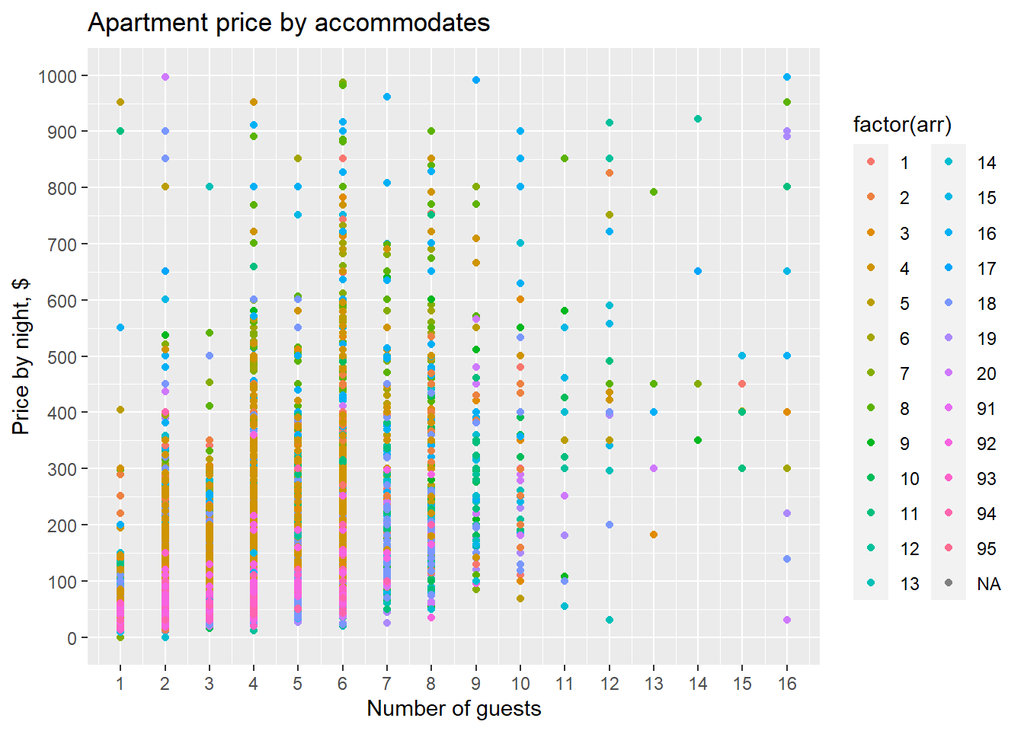

```r
ggplot(data = L_filtered) +
  geom_point(aes(x=accommodates, y=price, col=factor(arr))) +
  scale_x_continuous(breaks = seq(1,16,1)) +
  scale_y_continuous(breaks = seq(0,1000,100), limits = c(0,1000)) +
  ggtitle('Apartment price by accommodates') +
  xlab('Number of guests') +
  ylab('Price by night, $')
```

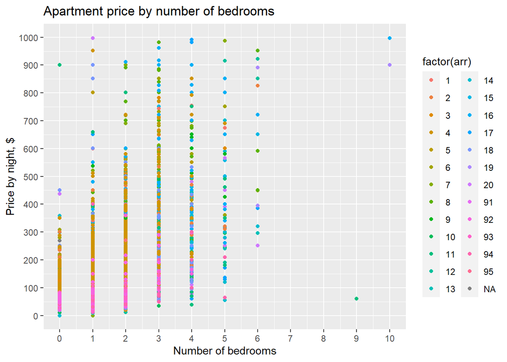

```r
ggplot(data = L_filtered) +
  geom_point(aes(x=bedrooms, y=price, col=factor(arr))) +
  scale_x_continuous(breaks = seq(0,10,1)) +
  scale_y_continuous(breaks = seq(0,1000,100), limits = c(0,1000)) +
  ggtitle('Apartment price by number of bedrooms') +
  xlab('Number of bedrooms') +
  ylab('Price by night, $')
```

## Renting price per city quarter (“arrondissements”):

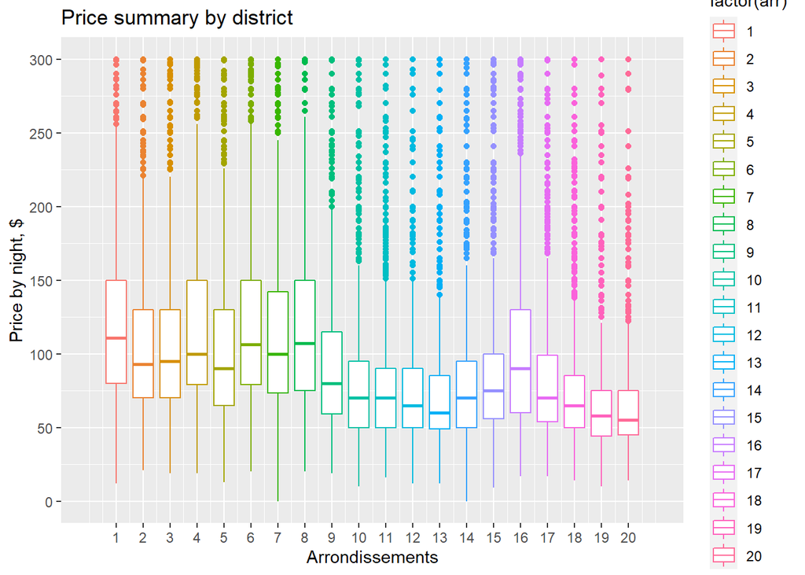

```r
ggplot(data = L_filtered) +
  geom_boxplot(aes(x=arr, y=price, col=factor(arr))) +
  scale_x_continuous(breaks = seq(1,20,1), limits = c(0,21)) +
  scale_y_continuous(breaks = seq(0,300,50), limits = c(0,300)) +
  ggtitle('Price summary by district') +
  xlab('Arrondissements') +
  ylab('Price by night, $')
```

## Visit frequency of the different quarters according to time:

```r
R$date <- as.Date(R$date, format = "%Y-%m-%d")
class(R$date)
```

```
## [1] "Date"
```

There are 663599 id listed in frequency table. Each apartment were listed `n` times:

```r
R %>% count(listing_id)%>%
  arrange(listing_id) %>%
  head(10)
```

```
##    listing_id   n
## 1        2623  66
## 2        4886  13
## 3        4890  11
## 4        5317   2
## 5        5396  82
## 6        6602  91
## 7        7397 141
## 8        8291  27
## 9        9279  14
## 10       9342  36
```

Number of all listings by year and month:

```r
R %>% mutate(month = format(date, '%m'), year = format(date, '%Y')) %>%
  count(year, month) %>%
  head(20)
```

```
##    year month   n
## 1  2009    05   1
## 2  2009    06   5
## 3  2009    07   4
## 4  2009    08   4
## 5  2009    09   7
## 6  2009    10   3
## 7  2009    11   6
## 8  2009    12   9
## 9  2010    01  15
## 10 2010    02  11
## 11 2010    03  22
## 12 2010    04  39
## 13 2010    05  69
## 14 2010    06  63
## 15 2010    07  85
## 16 2010    08  84
## 17 2010    09 151
## 18 2010    10 165
## 19 2010    11 105
## 20 2010    12  92
```

## Visit frequency all the time:

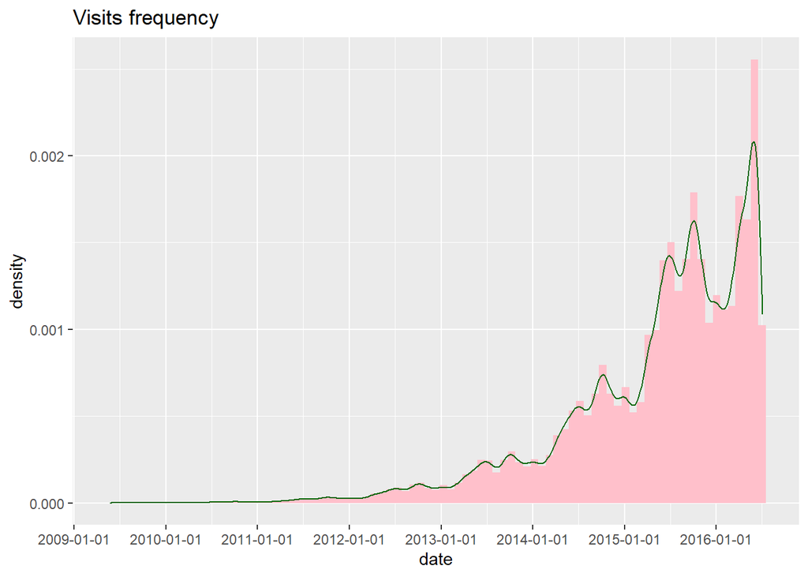

```r
ggplot(data=R) +
  geom_histogram(aes(x=date, y= ..density..), bins = 87, fill='pink') +
  geom_density(aes(x=date), col='darkgreen') +
  ggtitle('Visits frequency') +
  scale_x_date(date_breaks = '1 year')
```

## Visit frequency by districts by years:

```r
L_join <- L_filtered %>% select(id, arr)
R_join <- R
colnames(R_join) <- c('id', 'date')

joined <- inner_join(L_join, R_join, by = 'id')
joined <- mutate(joined, month = format(date, '%m'), year = format(date, '%Y'))
head(joined, 5)
```

```
##         id arr       date month year
## 1  4867396  17 2015-05-19    05 2015
## 2  2725029  17 2015-10-10    10 2015
## 3  9337509  17 2015-12-15    12 2015
## 4 12928158  17 2016-06-17    06 2016
## 5 12928158  17 2016-06-17    06 2016
```

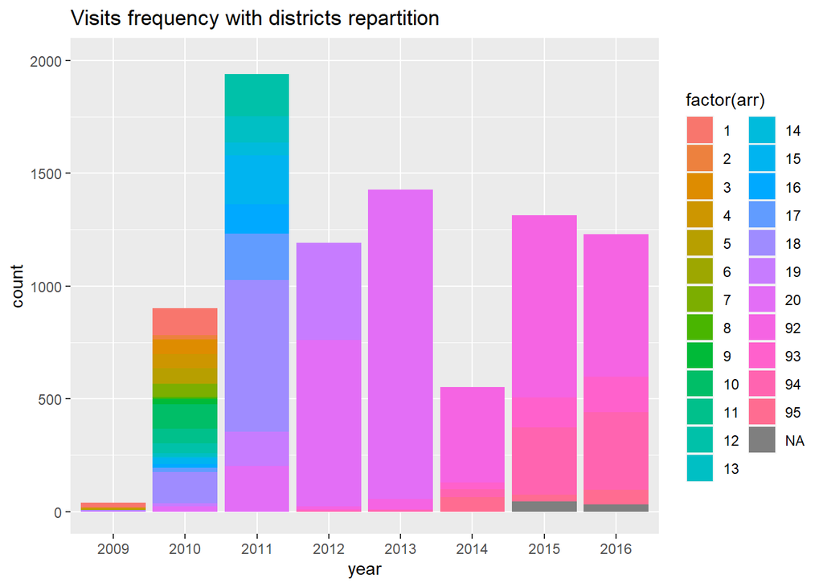

```r
ggplot(data = joined) +
  geom_bar(aes(x = year, fill=factor(arr))) +
  ggtitle('Visits frequency with districts repartition') +
  ylim(c(0,2000))
```

```r
# WTF ?!!
sum(is.na(L_filtered$arr))
```

```
## [1] 14
```

```r
sum(is.na(joined$arr))
```

```
## [1] 77
```

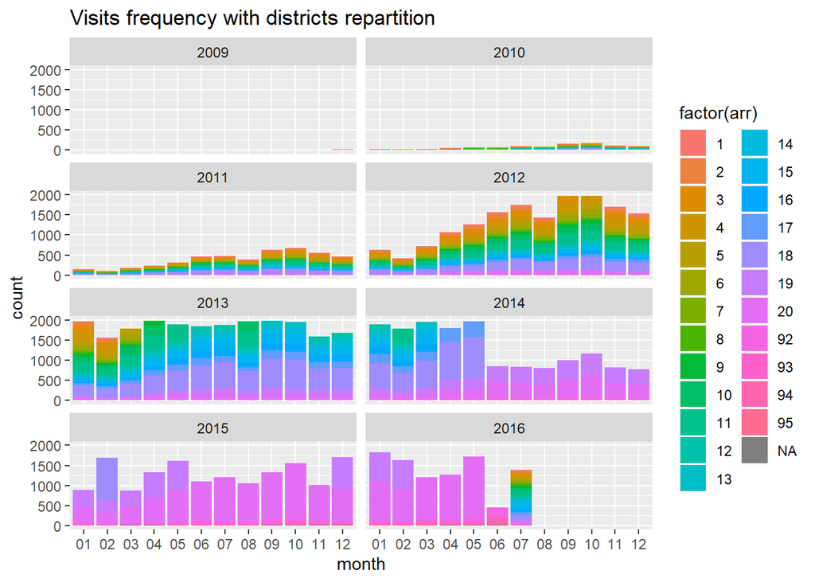

```r
ggplot(data = joined) +
  geom_bar(aes(x = month, fill= factor(arr))) +
  ggtitle('Visits frequency with districts repartition') +
  ylim(c(0,2000)) +
  facet_wrap(~year, nrow=4)
```